# classwork

Elise Haylett

2/4/2020

## Classwork

### Loading in the packages

```r
library(tidyverse)
```

### Mileage Dataset

```r
mileage <- read_csv(file = url("https://raw.githubusercontent.com/STAT-JET-ASU/Datasets/master/Instructor/gasmileage.csv"))
glimpse(mileage)
```

```
## Observations: 100
## Variables: 1
## $ mpg <dbl> 36.3, 41.0, 36.9, 37.1, 44.9, 36.8, 30.0, 37.2, 42.1, 36.7, 32.7,…
```

### Geyser Dataset

```r
oldfaithful <- read_csv(file = url("https://raw.githubusercontent.com/STAT-JET-ASU/Datasets/master/Instructor/oldfaithful.csv"))
glimpse(oldfaithful)
```

```
## Observations: 272
## Variables: 2
## $ erupt_time <dbl> 3.600, 1.800, 3.333, 2.283, 4.533, 2.883, 4.700, 3.600, 1.…
## $ wait_time  <dbl> 79, 54, 74, 62, 85, 55, 88, 85, 51, 85, 54, 84, 78, 47, 83…
```

### Wells Dataset

```r
wells <- read_csv(file = url("https://raw.githubusercontent.com/STAT-JET-ASU/Datasets/master/Chihara/Bangladesh.csv"))
glimpse(wells)
```

```
## Observations: 271
## Variables: 3
## $ Arsenic  <dbl> 2400, 6, 904, 321, 1280, 151, 141, 1050, 511, 688, 81, 8, 37…
## $ Chlorine <dbl> 6.2, 116.0, 14.8, 35.9, 18.9, 7.8, 56.3, 16.0, 40.4, 29.3, 3…
## $ Cobalt   <dbl> 0.42, 0.45, 0.63, 0.68, 0.58, 0.35, 0.46, 0.59, 0.48, 0.87, …
```

### Histograms

Histogram * modified bar plot * cut the x-axis into equally sized chunks/intervals/“bins” ** there can be no gaps ** must cover the whole range of the data * count how many data values are in each “bin”

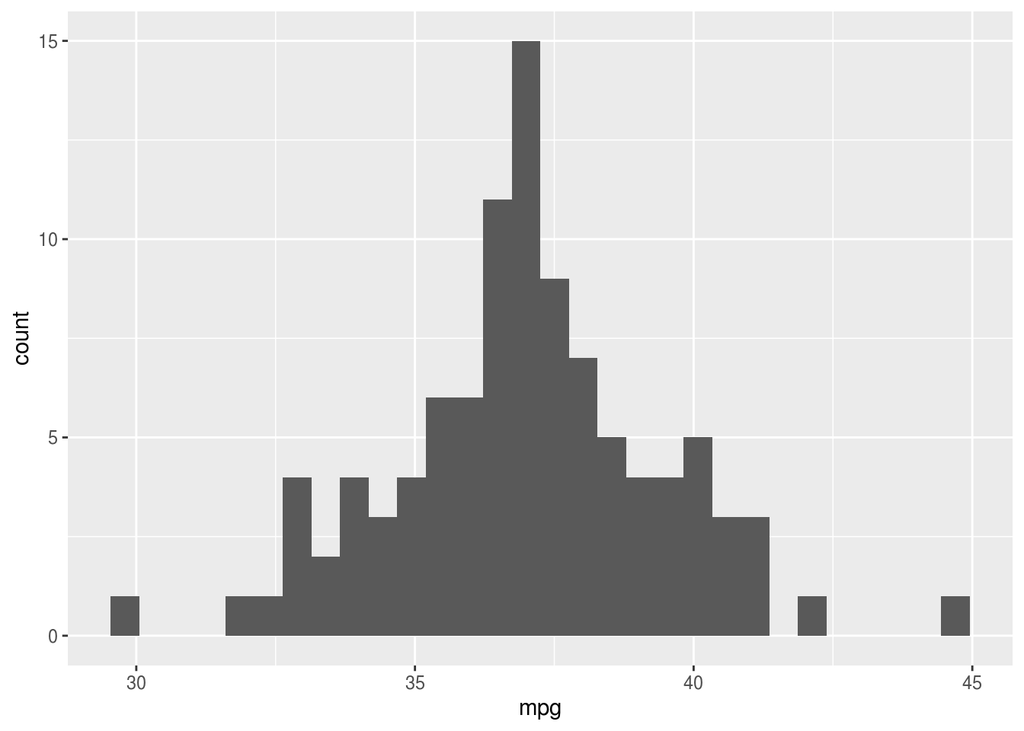

```r
#uni modal data, follows a normal distribution
ggplot(mileage, aes(x = mpg)) +
  geom_histogram()
```

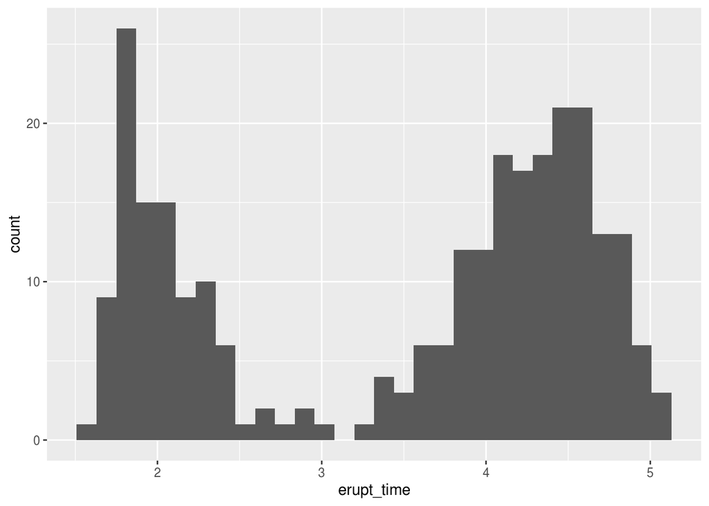

```r
#bimodal
ggplot(oldfaithful, aes(x = erupt_time)) +
  geom_histogram()
```

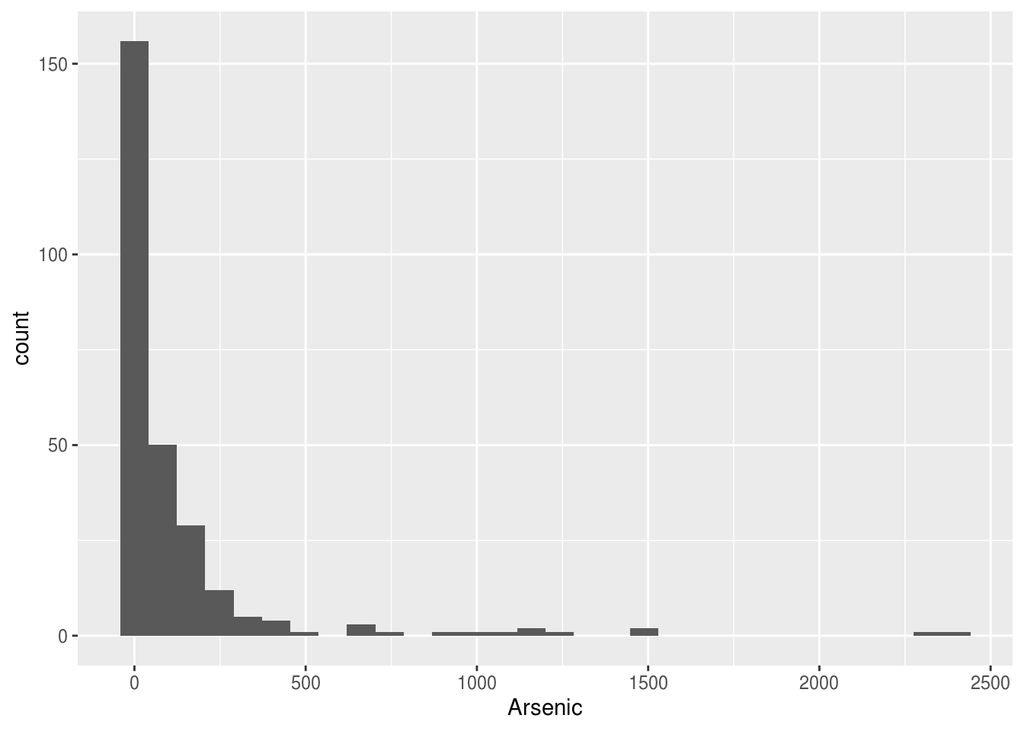

```r
#extremely right skewed data
ggplot(wells, aes(x = Arsenic)) +
  geom_histogram()
```

### Density Plots

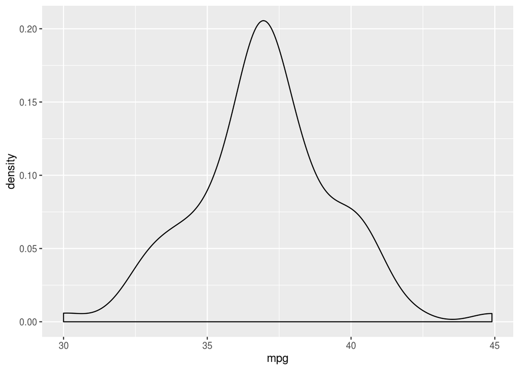

```r
ggplot(mileage, aes(x = mpg)) +
  geom_density()
```

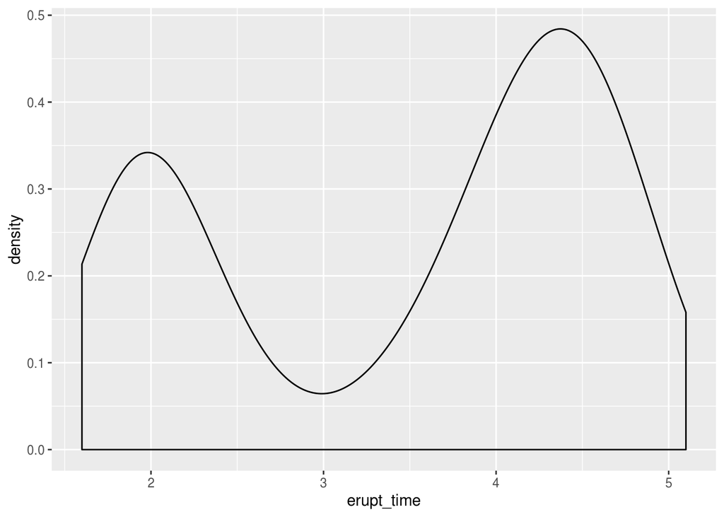

```r
ggplot(oldfaithful, aes(x = erupt_time)) +
  geom_density()
```

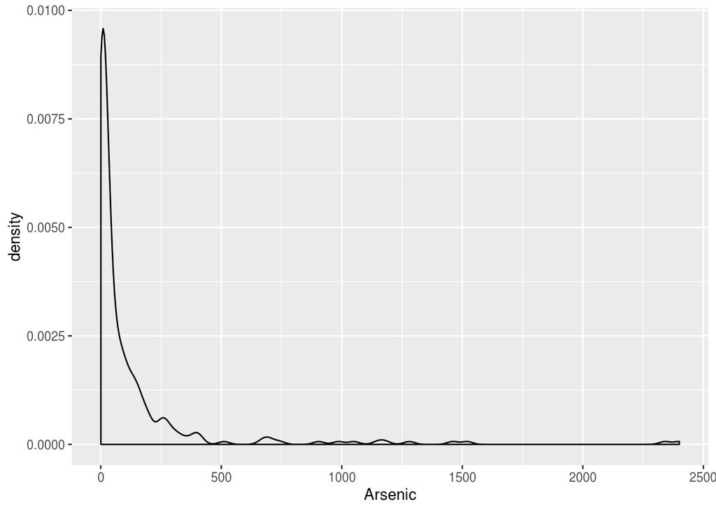

```r
ggplot(wells, aes(x = Arsenic)) +
  geom_density()
```

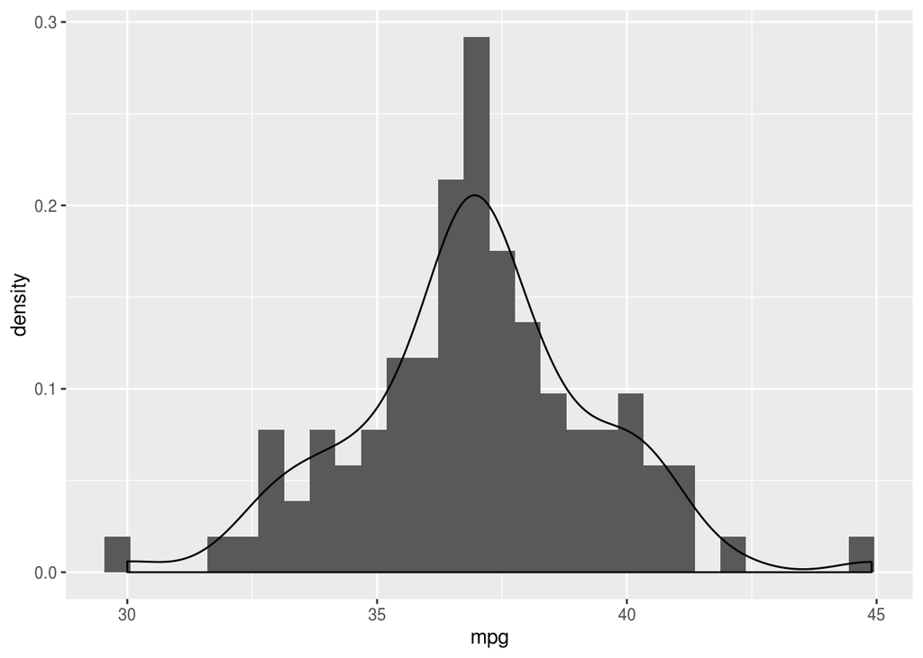

```r
ggplot(mileage, aes(x = mpg)) +
  geom_histogram(aes(y = ..density..)) +
  geom_density()
```

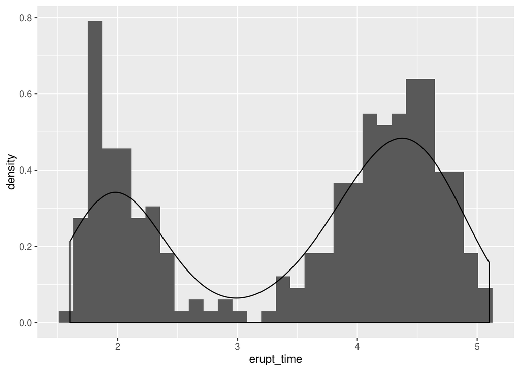

```r
ggplot(oldfaithful, aes(x = erupt_time)) +
  geom_histogram(aes(y = ..density..)) +
  geom_density()
```

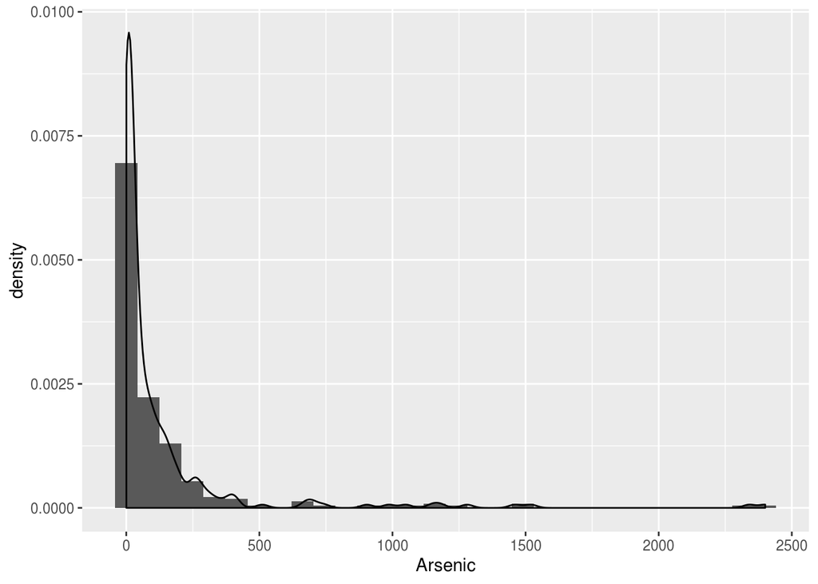

```r
ggplot(wells, aes(x = Arsenic)) +
  geom_histogram(aes(y = ..density..)) +
  geom_density()
```

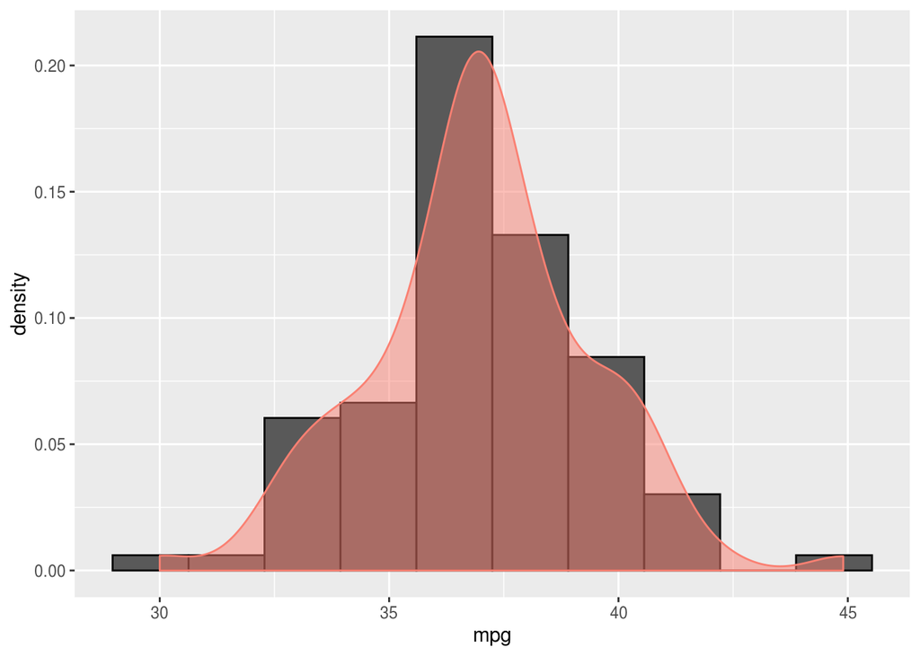

```r
ggplot(mileage, aes(x = mpg)) +
  geom_histogram(aes(y = ..density..), bins = 10, color = "black") +
  geom_density(fill = "salmon", color = "salmon", alpha = 0.50)
```

### Stat_ecdf

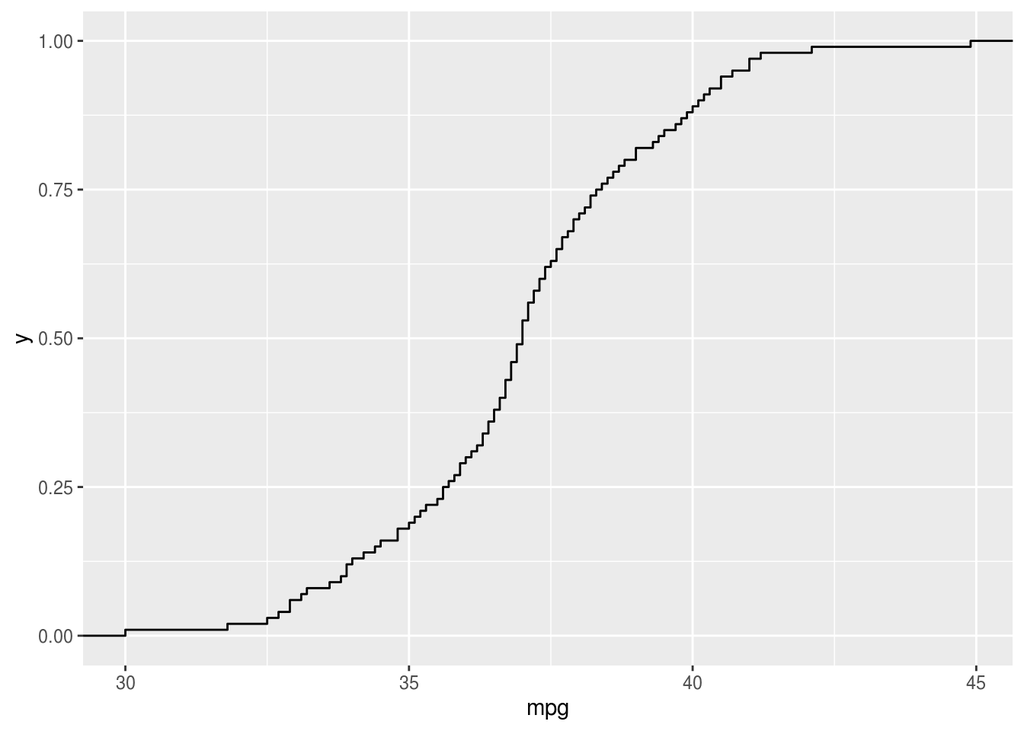

```r
ggplot(mileage, aes(x = mpg)) +
  stat_ecdf()
```

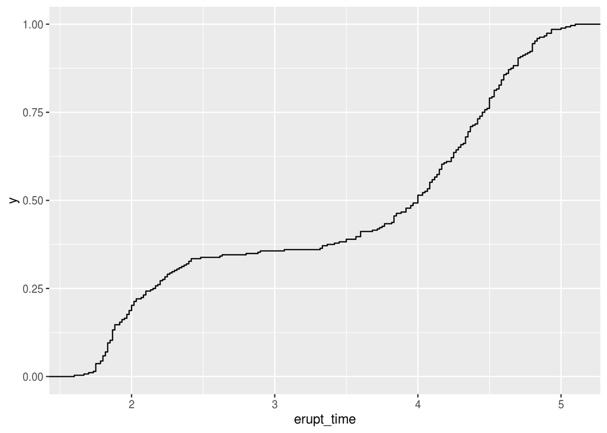

```r
ggplot(oldfaithful, aes(x = erupt_time)) +
  stat_ecdf()
```

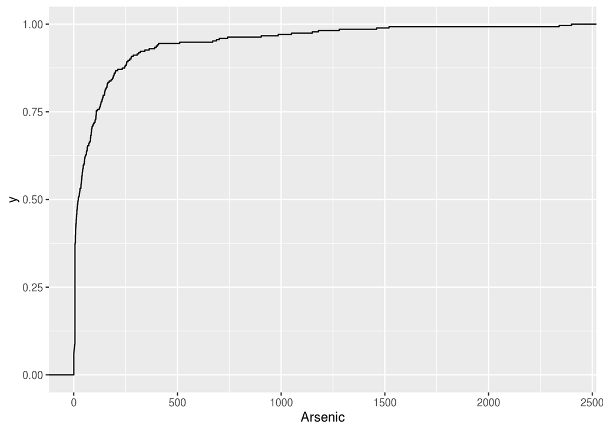

```r
ggplot(wells, aes(x = Arsenic)) +
  stat_ecdf()
```

### Z-score

> Z-score * Z-score is a unitless magnitude that will tell us distance

$$\frac{x - \mu}{\sigma} = z-score,$$
* $\mu$ = mean * $\sigma$ = sd * $x-\mu$ -> distance of point from mean * $\sigma$ -> roughly the average distance of all points + note: units will cancel each other out

### Skewness and kurtosis

> Skewness and kurtosis * skewness - third moment * how you quantify skewness: ** in perfectly symmetric data, the data will cancel each other out and the third moment/skewness = 0 * kurotsis can only be positive * kurtosis of a bell curve is 3 * kurtosis - fourth moment

anything that affects the mean and the standard deviation will affect the four moments

moment-based summaries in R - mean() - var() - sd() - skewness() - kurtosis(), in the `moments` package in r

```r
(mean(mileage$mpg))
```

```
## [1] 36.994
```

```r
(sd(mileage$mpg))
```

```
## [1] 2.417897
```

```r
# on average, points are spread out about 2.42 mpg above and below the mean

library(moments)
(skewness(mileage$mpg))
```

```
## [1] 0.05014194
```

```r
(kurtosis(mileage$mpg))
```

```
## [1] 3.672556
```

### 5 number summary

> 5-Number Summary * minimum, Q1, median, Q3, maxium * IQR = Q3 - Q1 — range of the middle 50% of the data * Range = max - min * Percentiles ** Q1 = 25th percentile/quantile ** Median = 50th percentile/quantile ** Q3 = 75th percentile/quantile

```r
fivenum(mileage$mpg)
```

```
## [1] 30.00 35.65 37.00 38.35 44.90
```

```r
fivenum(mileage$mpg)[1]
```

```
## [1] 30
```

```r
range(mileage$mpg)
```

```
## [1] 30.0 44.9
```

```r
diff(range(mileage$mpg))
```

```
## [1] 14.9
```

```r
quantile(mileage$mpg, c(.25, .5, .75))
```

```
##    25%    50%    75%
## 35.675 37.000 38.325
```

```r
quantile(mileage$mpg, seq(.1, .9, .1))
```

```
##   10%   20%   30%   40%   50%   60%   70%   80%   90%
## 33.89 35.18 36.07 36.66 37.00 37.34 37.93 38.84 40.11
```

```r
#quartiles by 4 (.25, .5, .75)
#quintiles by 5 (.20, .40, .60, .80)
#deciles by 4 (.10, .20, .30, .40,..., .90)
```

```r
xbar <- mean(mileage$mpg)
s <- sd(mileage$mpg)

mileage <- mileage %>%
  mutate(zscores = (mpg - xbar)/s,
         kpl = 0.43 * mpg,
         zscoresm = (kpl - mean(mileage$kpl))/sd(mileage$kpl)
  )
head(mileage)
```

```
## # A tibble: 6 x 4
##     mpg zscores   kpl zscoresm
##   <dbl>   <dbl> <dbl>    <dbl>
## 1  36.3 -0.287   15.6       NA
## 2  41    1.66    17.6       NA
## 3  36.9 -0.0389  15.9       NA
## 4  37.1  0.0438  16.0       NA
## 5  44.9  3.27    19.3       NA
## 6  36.8 -0.0802  15.8       NA
```